# **Problem Statement**

## Business Context

A sales forecast is a prediction of future sales revenue based on historical data, industry trends, and the status of the current sales pipeline. Businesses use the sales forecast to estimate weekly, monthly, quarterly, and annual sales totals. A company needs to make an accurate sales forecast as it adds value across an organization and helps the different verticals to chalk out their future course of action.

Forecasting helps an organization plan its sales operations by region and provides valuable insights to the supply chain team regarding the procurement of goods and materials. An accurate sales forecast process has many benefits which include improved decision-making about the future and reduction of sales pipeline and forecast risks. Moreover, it helps to reduce the time spent in planning territory coverage and establish benchmarks that can be used to assess trends in the future.

## Objective

SuperKart is a retail chain operating supermarkets and food marts across various tier cities, offering a wide range of products. To optimize its inventory management and make informed decisions around regional sales strategies, SuperKart wants to accurately forecast the sales revenue of its outlets for the upcoming quarter.

To operationalize these insights at scale, the company has partnered with a data science firm—not just to build a predictive model based on historical sales data, but to develop and deploy a robust forecasting solution that can be integrated into SuperKart’s decision-making systems and used across its network of stores.

## Data Description

The data contains the different attributes of the various products and stores.The detailed data dictionary is given below.

- **Product_Id** - unique identifier of each product, each identifier having two letters at the beginning followed by a number.
- **Product_Weight** - weight of each product
- **Product_Sugar_Content** - sugar content of each product like low sugar, regular and no sugar
- **Product_Allocated_Area** - ratio of the allocated display area of each product to the total display area of all the products in a store
- **Product_Type** - broad category for each product like meat, snack foods, hard drinks, dairy, canned, soft drinks, health and hygiene, baking goods, bread, breakfast, frozen foods, fruits and vegetables, household, seafood, starchy foods, others
- **Product_MRP** - maximum retail price of each product
- **Store_Id** - unique identifier of each store
- **Store_Establishment_Year** - year in which the store was established
- **Store_Size** - size of the store depending on sq. feet like high, medium and low
- **Store_Location_City_Type** - type of city in which the store is located like Tier 1, Tier 2 and Tier 3. Tier 1 consists of cities where the standard of living is comparatively higher than its Tier 2 and Tier 3 counterparts.
- **Store_Type** - type of store depending on the products that are being sold there like Departmental Store, Supermarket Type 1, Supermarket Type 2 and Food Mart
- **Product_Store_Sales_Total** - total revenue generated by the sale of that particular product in that particular store

# **Installing and Importing the necessary libraries**

```python
#Installing the libraries with the specified versions
!pip install numpy==2.0.2 pandas==2.2.2 scikit-learn==1.6.1 matplotlib==3.10.0 seaborn==0.13.2 joblib==1.4.2 xgboost==2.1.4 requests==2.32.4 huggingface_hub==0.34.0 -q
```

**Note:**

- After running the above cell, kindly restart the notebook kernel (for Jupyter Notebook) or runtime (for Google Colab) and run all cells sequentially from the next cell.
- On executing the above line of code, you might see a warning regarding package dependencies. This error message can be ignored as the above code ensures that all necessary libraries and their dependencies are maintained to successfully execute the code in this notebook.

```python
import warnings
warnings.filterwarnings("ignore")

# Libraries to help with reading and manipulating data
import numpy as np
import pandas as pd

# For splitting the dataset
from sklearn.model_selection import train_test_split

# Libaries to help with data visualization
import matplotlib.pyplot as plt
import seaborn as sns

# Removes the limit for the number of displayed columns
pd.set_option("display.max_columns", None)
# Sets the limit for the number of displayed rows
pd.set_option("display.max_rows", 100)


# Libraries different ensemble classifiers
from sklearn.ensemble import (
    BaggingRegressor,
    RandomForestRegressor,
    AdaBoostRegressor,
    GradientBoostingRegressor,
)
from xgboost import XGBRegressor
from sklearn.tree import DecisionTreeRegressor

# Libraries to get different metric scores
from sklearn.metrics import (
    confusion_matrix,
    accuracy_score,
    precision_score,
    recall_score,
    f1_score,
    mean_squared_error,
    mean_absolute_error,
    r2_score,
    mean_absolute_percentage_error
)

# To create the pipeline
from sklearn.compose import make_column_transformer
from sklearn.pipeline import make_pipeline,Pipeline

# To tune different models and standardize
from sklearn.model_selection import GridSearchCV
from sklearn.preprocessing import StandardScaler,OneHotEncoder

# To serialize the model
import joblib

# os related functionalities
import os

# API request
import requests

# for hugging face space authentication to upload files
from huggingface_hub import login, HfApi
```

# **Loading the dataset**

```python
from google.colab import drive
drive.mount('/content/drive')

df = pd.read_csv('/content/drive/My Drive/Colab/MD Proj/SuperKart.csv')
print(df.head())
```

```
  Product_Id  Product_Weight Product_Sugar_Content  Product_Allocated_Area  \
0     FD6114           12.66             Low Sugar                   0.027
1     FD7839           16.54             Low Sugar                   0.144
2     FD5075           14.28               Regular                   0.031
3     FD8233           12.10             Low Sugar                   0.112
4     NC1180            9.57              No Sugar                   0.010

         Product_Type  Product_MRP Store_Id  Store_Establishment_Year  \
0        Frozen Foods       117.08   OUT004                      2009
1               Dairy       171.43   OUT003                      1999
2              Canned       162.08   OUT001                      1987
3        Baking Goods       186.31   OUT001                      1987
4  Health and Hygiene       123.67   OUT002                      1998

  Store_Size Store_Location_City_Type          Store_Type  \
0     Medium                   Tier 2   Supermarket Type2
1     Medium                   Tier 1  Departmental Store
2       High                   Tier 2   Supermarket Type1
3       High                   Tier 2   Supermarket Type1
4      Small                   Tier 3           Food Mart

   Product_Store_Sales_Total
0                    2842.40
1                    4830.02
2                    4130.16
3                    4132.18
4                    2279.36
```

# **Data Overview**

```python
print("First 5 rows of the DataFrame:")
print(df.head())
print("\n" + "-"*50 + "\n")
```

```
First 5 rows of the DataFrame:
  Product_Id  Product_Weight Product_Sugar_Content  Product_Allocated_Area  \
0     FD6114           12.66             Low Sugar                   0.027
1     FD7839           16.54             Low Sugar                   0.144
2     FD5075           14.28               Regular                   0.031
3     FD8233           12.10             Low Sugar                   0.112
4     NC1180            9.57              No Sugar                   0.010

         Product_Type  Product_MRP Store_Id  Store_Establishment_Year  \
0        Frozen Foods       117.08   OUT004                      2009
1               Dairy       171.43   OUT003                      1999
2              Canned       162.08   OUT001                      1987
3        Baking Goods       186.31   OUT001                      1987
4  Health and Hygiene       123.67   OUT002                      1998

  Store_Size Store_Location_City_Type          Store_Type  \
0     Medium                   Tier 2   Supermarket Type2
1     Medium                   Tier 1  Departmental Store
2       High                   Tier 2   Supermarket Type1
3       High                   Tier 2   Supermarket Type1
4      Small                   Tier 3           Food Mart

   Product_Store_Sales_Total
0                    2842.40
1                    4830.02
2                    4130.16
3                    4132.18
4                    2279.36

--------------------------------------------------
```

```python
print("Shape of the dataset:", df.shape)
print("\n" + "-"*50 + "\n")
```

```
Shape of the dataset: (8763, 12)

--------------------------------------------------
```

```python
print("Missing values count per column:")
print(df.isnull().sum())
print("\n" + "-"*50 + "\n")
```

```
Missing values count per column:
Product_Id                   0
Product_Weight               0
Product_Sugar_Content        0
Product_Allocated_Area       0
Product_Type                 0
Product_MRP                  0
Store_Id                     0
Store_Establishment_Year     0
Store_Size                   0
Store_Location_City_Type     0
Store_Type                   0
Product_Store_Sales_Total    0
dtype: int64

--------------------------------------------------
```

```python
initial_rows = df.shape[0]
df.drop_duplicates(inplace=True)
final_rows = df.shape[0]
print(f"Number of duplicate rows found and removed: {initial_rows - final_rows}")
print("Shape after dropping duplicates:", df.shape)
print("\n" + "-"*50 + "\n")
```

```
Number of duplicate rows found and removed: 0
Shape after dropping duplicates: (8763, 12)

--------------------------------------------------
```

```python
print("Data types of all columns:")
print(df.info())
```

```
Data types of all columns:
<class 'pandas.core.frame.DataFrame'>
RangeIndex: 8763 entries, 0 to 8762
Data columns (total 12 columns):
 #   Column                     Non-Null Count  Dtype
---  ------                     --------------  -----
 0   Product_Id                 8763 non-null   object
 1   Product_Weight             8763 non-null   float64
 2   Product_Sugar_Content      8763 non-null   object
 3   Product_Allocated_Area     8763 non-null   float64
 4   Product_Type               8763 non-null   object
 5   Product_MRP                8763 non-null   float64
 6   Store_Id                   8763 non-null   object
 7   Store_Establishment_Year   8763 non-null   int64
 8   Store_Size                 8763 non-null   object
 9   Store_Location_City_Type   8763 non-null   object
 10  Store_Type                 8763 non-null   object
 11  Product_Store_Sales_Total  8763 non-null   float64
dtypes: float64(4), int64(1), object(7)
memory usage: 821.7+ KB
None
```

# **Exploratory Data Analysis (EDA)**

## 1. Plot histograms for numerical columns

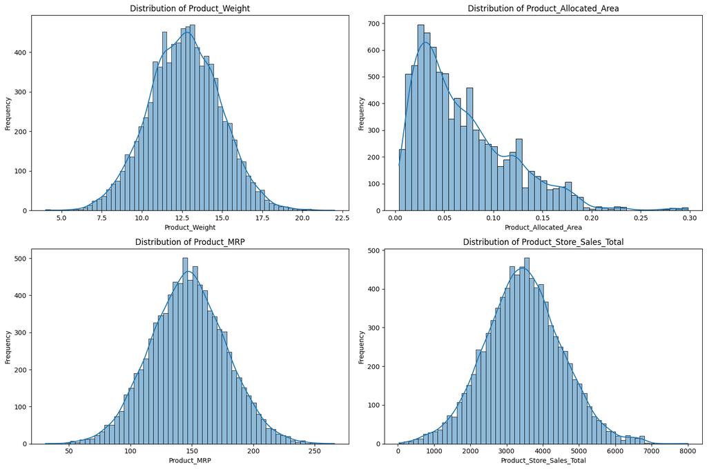

```python
plt.figure(figsize=(15, 10))

num_cols_hist = ['Product_Weight', 'Product_Allocated_Area', 'Product_MRP', 'Product_Store_Sales_Total']
for i, col in enumerate(num_cols_hist):
    plt.subplot(2, 2, i + 1)
    sns.histplot(df[col], kde=True)
    plt.title(f'Distribution of {col}')
    plt.xlabel(col)
    plt.ylabel('Frequency')
plt.tight_layout()
plt.show()
```

## 2. Create countplots for categorical columns

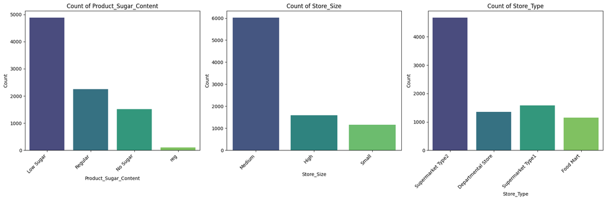

```python
plt.figure(figsize=(18, 6))

cat_cols_countplot = ['Product_Sugar_Content', 'Store_Size', 'Store_Type']
for i, col in enumerate(cat_cols_countplot):
    plt.subplot(1, 3, i + 1)
    sns.countplot(data=df, x=col, palette='viridis')
    plt.title(f'Count of {col}')
    plt.xlabel(col)
    plt.ylabel('Count')
    plt.xticks(rotation=45, ha='right') # Rotate labels for better readability
plt.tight_layout()
plt.show()
```

The Product_Sugar_Content has both "Regular" and "reg" which looks like a mistake in the data. We can consolidate these two types into "Regular" during the data preprocessing.

## Check categorical data to see if there are any other mismatched data.

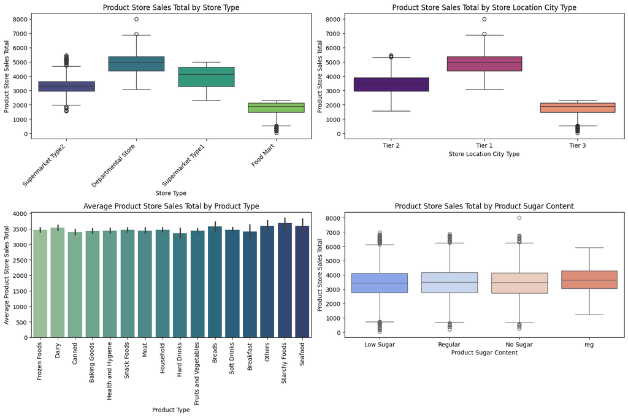

```python
plt.figure(figsize=(15, 10))

# 1. Boxplot: 'Store_Type' vs 'Product_Store_Sales_Total'
plt.subplot(2, 2, 1)
sns.boxplot(data=df, x='Store_Type', y='Product_Store_Sales_Total', palette='viridis')
plt.title('Product Store Sales Total by Store Type')
plt.xlabel('Store Type')
plt.ylabel('Product Store Sales Total')
plt.xticks(rotation=45, ha='right')

# 2. Boxplot: 'Store_Location_City_Type' vs 'Product_Store_Sales_Total'
plt.subplot(2, 2, 2)
sns.boxplot(data=df, x='Store_Location_City_Type', y='Product_Store_Sales_Total', palette='magma')
plt.title('Product Store Sales Total by Store Location City Type')
plt.xlabel('Store Location City Type')
plt.ylabel('Product Store Sales Total')

# 3. Barplot: 'Product_Type' vs 'Product_Store_Sales_Total' (showing the Mean)
plt.subplot(2, 2, 3)
sns.barplot(data=df, x='Product_Type', y='Product_Store_Sales_Total', estimator=np.mean, palette='crest')
plt.title('Average Product Store Sales Total by Product Type')
plt.xlabel('Product Type')
plt.ylabel('Average Product Store Sales Total')
plt.xticks(rotation=90, ha='center') # Rotate x-axis labels 90 degrees

# 4. Boxplot: 'Product_Sugar_Content' vs 'Product_Store_Sales_Total'
plt.subplot(2, 2, 4)
sns.boxplot(data=df, x='Product_Sugar_Content', y='Product_Store_Sales_Total', palette='coolwarm')
plt.title('Product Store Sales Total by Product Sugar Content')
plt.xlabel('Product Sugar Content')
plt.ylabel('Product Store Sales Total')

plt.tight_layout()
plt.show()
```

## 3. Create a Correlation Heatmap for all numerical variables

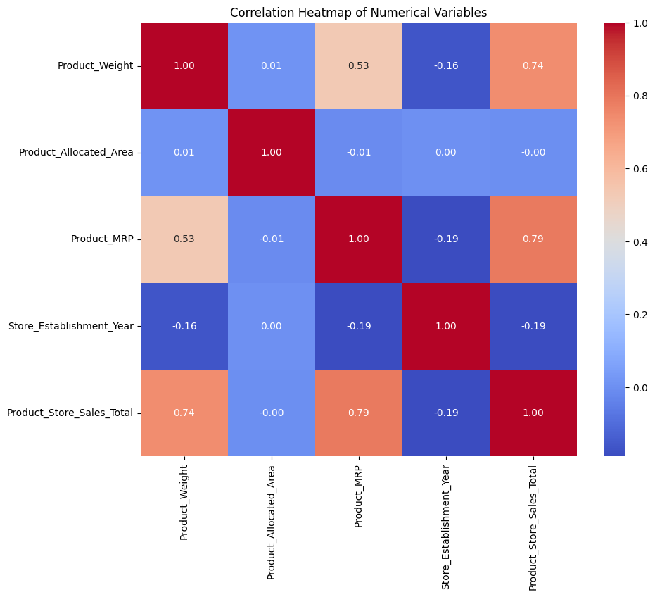

```python
plt.figure(figsize=(10, 8))

# Select only numerical columns for correlation
numerical_df = df.select_dtypes(include=['float64', 'int64'])
corr_matrix = numerical_df.corr()
sns.heatmap(corr_matrix, annot=True, cmap='coolwarm', fmt=".2f")
plt.title('Correlation Heatmap of Numerical Variables')
plt.show()
```

## 4. Create a scatterplot showing the relationship between 'Product_MRP' and 'Product_Store_Sales_Total'

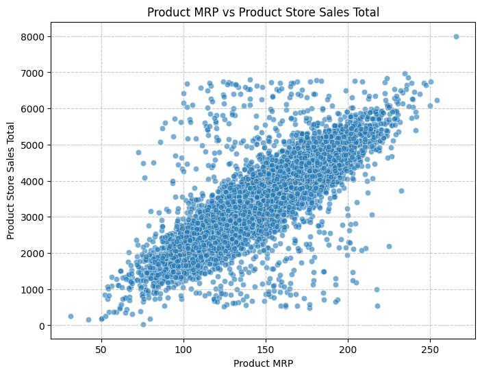

```python
plt.figure(figsize=(8, 6))
sns.scatterplot(data=df, x='Product_MRP', y='Product_Store_Sales_Total', alpha=0.6)
plt.title('Product MRP vs Product Store Sales Total')
plt.xlabel('Product MRP')
plt.ylabel('Product Store Sales Total')
plt.grid(True, linestyle='--', alpha=0.7)
plt.show()
```

# **Data Preprocessing**

```python
df['Product_Sugar_Content'] = df['Product_Sugar_Content'].replace('reg', 'Regular')
print("Data Cleaning complete: 'reg' replaced with 'Regular'.")
print(f"Shape after cleaning: {df.shape}\n")

df_processed = df.drop(columns=['Store_Id', 'Product_Id'])
print("'Store_Id', 'Product_Id' dropped.")
print(f"Shape after dropping columns: {df_processed.shape}\n")
```

```
Data Cleaning complete: 'reg' replaced with 'Regular'.
Shape after cleaning: (8763, 12)

'Store_Id', 'Product_Id' dropped.
Shape after dropping columns: (8763, 10)
```

```python
# split data into training and testing sets.
X = df_processed.drop('Product_Store_Sales_Total', axis=1)
y = df_processed['Product_Store_Sales_Total']

X_train, X_test, y_train, y_test = train_test_split(X, y, test_size=0.2, random_state=42)
```

```python
print(f"\nShape of X_train: {X_train.shape}")
print(f"Shape of X_test: {X_test.shape}")
```

```
Shape of X_train: (7010, 9)
Shape of X_test: (1753, 9)
```

# **Model Building**

## Define functions for Model Evaluation

```python
# function to compute adjusted R-squared
def adj_r2_score(predictors, targets, predictions):
    r2 = r2_score(targets, predictions)
    n = predictors.shape[0]
    k = predictors.shape[1]
    return 1 - ((1 - r2) * (n - 1) / (n - k - 1))


# function to compute different metrics to check performance of a regression model
def model_performance_regression(model, predictors, target):
    """
    Function to compute different metrics to check regression model performance

    model: regressor
    predictors: independent variables
    target: dependent variable
    """

    # predicting using the independent variables
    pred = model.predict(predictors)

    r2 = r2_score(target, pred)  # to compute R-squared
    adjr2 = adj_r2_score(predictors, target, pred)  # to compute adjusted R-squared
    rmse = np.sqrt(mean_squared_error(target, pred))  # to compute RMSE
    mae = mean_absolute_error(target, pred)  # to compute MAE
    mape = mean_absolute_percentage_error(target, pred)  # to compute MAPE

    # creating a dataframe of metrics
    df_perf = pd.DataFrame(
        {
            "RMSE": rmse,
            "MAE": mae,
            "R-squared": r2,
            "Adj. R-squared": adjr2,
            "MAPE": mape,
        },
        index=[0],
    )

    return df_perf
```

The ML models to be built can be any two out of the following:

1. Decision Tree
2. Bagging
3. Random Forest
4. AdaBoost
5. Gradient Boosting
6. XGBoost

# **Rationale for Model Selection**

We will select **Random Forest** and **XGBoost** because tree-based ensembles will perform well with structured sales data. They excel at capturing non-linear relationships (like between *Price* and *Location*) without requiring complex feature scaling.

### **1. Random Forest Regressor (Bagging)**

- This will be our baseline.
- Random Forest's averaging of predictions reduces overfitting.
- Be able to train with our features with minimal tuning.

### **2. XGBoost Regressor (Boosting)**

- XGBoost is well trusted to perform well.
- XGBoost can optimize to squeeze out maximum accuracy.
- It handles One-Hot Encoding better than standard trees.

## Baseline Models

```python
param_grid = {
    'n_estimators': [100, 200, 300],
    'max_depth': [10, 20, None]
}

print("RandomForestRegressor parameter grid defined:")
print(param_grid)
```

```
RandomForestRegressor parameter grid defined:
{'n_estimators': [100, 200, 300], 'max_depth': [10, 20, None]}
```

```python
from sklearn.model_selection import GridSearchCV
from sklearn.ensemble import RandomForestRegressor
from sklearn.preprocessing import OneHotEncoder, StandardScaler
from sklearn.compose import ColumnTransformer
from sklearn.pipeline import Pipeline

# Identify categorical and numerical features
# Re-extract these from X_train to ensure correctness
categorical_features = X_train.select_dtypes(include=['object']).columns
numerical_features = X_train.select_dtypes(include=['float64', 'int64']).columns

# Create a column transformer for preprocessing
preprocessor = ColumnTransformer(
    transformers=[
        ('num', StandardScaler(), numerical_features),
        ('cat', OneHotEncoder(handle_unknown='ignore'), categorical_features)
    ])

# Create a pipeline with the preprocessor and RandomForestRegressor
rf_pipeline = Pipeline(steps=[
    ('preprocessor', preprocessor),
    ('regressor', RandomForestRegressor(random_state=42))
])

# Define the parameter grid for the RandomForestRegressor within the pipeline
param_grid = {
    'regressor__n_estimators': [100, 200, 300],
    'regressor__max_depth': [10, 20, None]
}

# Instantiate GridSearchCV
grid_search_rf = GridSearchCV(
    estimator=rf_pipeline,
    param_grid=param_grid,
    cv=3,
    scoring='r2',
    n_jobs=-1, # Use all available cores for parallel processing
    verbose=2 # Verbosity level (higher means more messages)
)

print("Starting GridSearchCV for RandomForestRegressor...")
# Fit GridSearchCV to the training data
grid_search_rf.fit(X_train, y_train)

print("\nGridSearchCV complete.")
# Print the best parameters
print("Best parameters found: ", grid_search_rf.best_params_)

# Print the best R-squared score
print("Best R-squared score: {:.4f}".format(grid_search_rf.best_score_))
```

```
Starting GridSearchCV for RandomForestRegressor...
Fitting 3 folds for each of 9 candidates, totalling 27 fits

GridSearchCV complete.
Best parameters found:  {'regressor__max_depth': 10, 'regressor__n_estimators': 300}
Best R-squared score: 0.9263
```

### **The Baseline Model Overview**

**Objective & Methodology** To optimize the baseline **Random Forest Regressor**, we will use `GridSearchCV` with 3-fold CV.

**Key Findings & Performance**

- **Best Configuration:** The model achieved optimal performance with **`n_estimators=300`** and **`max_depth=10`**.
- **Score:** The best cross-validated **$R^2$ score was 0.9263**, indicating that the model explains approximately 92.6% of the variance in the target sales data.

**Insights** The selection of `max_depth=10` (as opposed to `20` or `None`) might suggest that a moderately constrained tree depth allows the model to train without overfitting.

```python
from sklearn.model_selection import GridSearchCV
from xgboost import XGBRegressor
from sklearn.preprocessing import OneHotEncoder, StandardScaler
from sklearn.compose import ColumnTransformer
from sklearn.pipeline import Pipeline

# 1. Identify categorical and numerical features
categorical_features = X_train.select_dtypes(include=['object']).columns
numerical_features = X_train.select_dtypes(include=['float64', 'int64']).columns

# 2. Create a column transformer for preprocessing
preprocessor = ColumnTransformer(
    transformers=[
        ('num', StandardScaler(), numerical_features),
        ('cat', OneHotEncoder(handle_unknown='ignore'), categorical_features)
    ])

# 3. Create a pipeline with the preprocessor and XGBRegressor
xgb_pipeline = Pipeline(steps=[
    ('preprocessor', preprocessor),
    ('regressor', XGBRegressor(random_state=42)) # Using a fixed random_state for reproducibility
])

# 4. Define the parameter grid for the XGBRegressor within the pipeline
param_grid_xgb = {
    'regressor__n_estimators': [100, 200, 300],
    'regressor__max_depth': [3, 5, 7]
}

# 5. Instantiate GridSearchCV
grid_search_xgb = GridSearchCV(
    estimator=xgb_pipeline,
    param_grid=param_grid_xgb,
    cv=3, # Using 3-fold cross-validation
    scoring='r2', # Using R-squared as the scoring metric
    n_jobs=-1, # Use all available cores for parallel processing
    verbose=2 # Verbosity level (higher means more messages)
)

print("Starting GridSearchCV for XGBRegressor...")
# 6. Fit GridSearchCV to the training data
grid_search_xgb.fit(X_train, y_train)

print("\nGridSearchCV complete.")
# 7. Print the best parameters
print("Best parameters found: ", grid_search_xgb.best_params_)

# 8. Print the best R-squared score
print("Best R-squared score: {:.4f}".format(grid_search_xgb.best_score_))
```

```
Starting GridSearchCV for XGBRegressor...
Fitting 3 folds for each of 9 candidates, totalling 27 fits

GridSearchCV complete.
Best parameters found:  {'regressor__max_depth': 7, 'regressor__n_estimators': 100}
Best R-squared score: 0.9152
```

### **The XGBoost Model Overview**

**Objective & Methodology** To optimize the **XGBoost Regressor**, we utilized GridSearchCV with 3-fold CV to test various combinations of tree depth and the number of estimators.

**Key Findings & Performance**

- **Best Configuration**: The model achieved optimal performance with `n_estimators=100` and `max_depth=7`.

Score: The best cross-validated **R² score was 0.9152**, indicating that the model explains approximately **91.5%** of the variance in the target sales data.

XGBoost model performed very well, but it's trailing from the Random Forest baseline. We will tune both models to see which performs the best.

# **Model Performance Improvement - Hyperparameter Tuning**

Now that we have established baseline models, we want to see if we can improve the $R^2$ score by fine-tuning the hyperparameters.

We will use `GridSearchCV` to test a wider range of parameters for both **Random Forest** and **XGBoost**.

## Advanced Hyperparameter Tuning for Random Forest

Expanding the search grid for the Random Forest model:

```python
param_grid_rf_advanced = {
    'regressor__n_estimators': [150, 300, 450],
    'regressor__max_depth': [10, 20, 30, None],
    'regressor__min_samples_leaf': [1, 2, 4]
}

print("Expanded RandomForestRegressor parameter grid defined:")
print(param_grid_rf_advanced)
```

```
Expanded RandomForestRegressor parameter grid defined:
{'regressor__n_estimators': [150, 300, 450], 'regressor__max_depth': [10, 20, 30, None], 'regressor__min_samples_leaf': [1, 2, 4]}
```

```python
from sklearn.model_selection import GridSearchCV
from sklearn.ensemble import RandomForestRegressor
from sklearn.preprocessing import OneHotEncoder, StandardScaler
from sklearn.compose import ColumnTransformer
from sklearn.pipeline import Pipeline

# Identify categorical and numerical features
categorical_features = X_train.select_dtypes(include=['object']).columns
numerical_features = X_train.select_dtypes(include=['float64', 'int64']).columns

# Create a column transformer for preprocessing
preprocessor = ColumnTransformer(
    transformers=[
        ('num', StandardScaler(), numerical_features),
        ('cat', OneHotEncoder(handle_unknown='ignore'), categorical_features)
    ])

# Create a pipeline with the preprocessor and RandomForestRegressor
rf_pipeline = Pipeline(steps=[
    ('preprocessor', preprocessor),
    ('regressor', RandomForestRegressor(random_state=42))
])

# Instantiate GridSearchCV with the advanced parameter grid
grid_search_rf_advanced = GridSearchCV(
    estimator=rf_pipeline,
    param_grid=param_grid_rf_advanced,
    cv=3,
    scoring='r2',
    n_jobs=-1,
    verbose=2
)

print("Starting advanced GridSearchCV for RandomForestRegressor...")
# Fit GridSearchCV to the training data
grid_search_rf_advanced.fit(X_train, y_train)

print("\nAdvanced GridSearchCV complete for RandomForestRegressor.")
```

```
Starting advanced GridSearchCV for RandomForestRegressor...
Fitting 3 folds for each of 36 candidates, totalling 108 fits

Advanced GridSearchCV complete for RandomForestRegressor.
```

```python
print("Best parameters for RandomForestRegressor (advanced tuning): ", grid_search_rf_advanced.best_params_)
print("Best R-squared score for RandomForestRegressor (advanced tuning): {:.4f}".format(grid_search_rf_advanced.best_score_))
```

```
Best parameters for RandomForestRegressor (advanced tuning):  {'regressor__max_depth': 20, 'regressor__min_samples_leaf': 2, 'regressor__n_estimators': 450}
Best R-squared score for RandomForestRegressor (advanced tuning): 0.9280
```

## Advanced Hyperparameter Tuning for XGBoost

### **Tuning XGBoost**

We want to give the XGBoost model a fair chance to beat the Random Forest:

```python
param_grid_xgb_advanced = {
    'regressor__n_estimators': [150, 300, 450],
    'regressor__max_depth': [3, 5, 7, 9],
    'regressor__learning_rate': [0.01, 0.1, 0.2],
    'regressor__subsample': [0.7, 0.8, 0.9]
}

print("Expanded XGBRegressor parameter grid defined:")
print(param_grid_xgb_advanced)
```

```
Expanded XGBRegressor parameter grid defined:
{'regressor__n_estimators': [150, 300, 450], 'regressor__max_depth': [3, 5, 7, 9], 'regressor__learning_rate': [0.01, 0.1, 0.2], 'regressor__subsample': [0.7, 0.8, 0.9]}
```

```python
from sklearn.model_selection import GridSearchCV
from xgboost import XGBRegressor
from sklearn.preprocessing import OneHotEncoder, StandardScaler
from sklearn.compose import ColumnTransformer
from sklearn.pipeline import Pipeline

# Identify categorical and numerical features
categorical_features = X_train.select_dtypes(include=['object']).columns
numerical_features = X_train.select_dtypes(include=['float64', 'int64']).columns

# Create a column transformer for preprocessing
preprocessor = ColumnTransformer(
    transformers=[
        ('num', StandardScaler(), numerical_features),
        ('cat', OneHotEncoder(handle_unknown='ignore'), categorical_features)
    ])

# Create a pipeline with the preprocessor and XGBRegressor
xgb_pipeline = Pipeline(steps=[
    ('preprocessor', preprocessor),
    ('regressor', XGBRegressor(random_state=42)) # Using a fixed random_state for reproducibility
])

# Instantiate GridSearchCV with the advanced parameter grid
grid_search_xgb_advanced = GridSearchCV(
    estimator=xgb_pipeline,
    param_grid=param_grid_xgb_advanced,
    cv=3, # Using 3-fold cross-validation
    scoring='r2', # Using R-squared as the scoring metric
    n_jobs=-1, # Use all available cores for parallel processing
    verbose=2 # Verbosity level (higher means more messages)
)

print("Starting advanced GridSearchCV for XGBRegressor...")
# Fit GridSearchCV to the training data
grid_search_xgb_advanced.fit(X_train, y_train)

print("\nAdvanced GridSearchCV complete for XGBRegressor.")
```

```
Starting advanced GridSearchCV for XGBRegressor...
Fitting 3 folds for each of 108 candidates, totalling 324 fits

Advanced GridSearchCV complete for XGBRegressor.
```

```python
print("Best parameters for XGBRegressor (advanced tuning): ", grid_search_xgb_advanced.best_params_)
print("Best R-squared score for XGBRegressor (advanced tuning): {:.4f}".format(grid_search_xgb_advanced.best_score_))
```

```
Best parameters for XGBRegressor (advanced tuning):  {'regressor__learning_rate': 0.01, 'regressor__max_depth': 7, 'regressor__n_estimators': 450, 'regressor__subsample': 0.7}
Best R-squared score for XGBRegressor (advanced tuning): 0.9261
```

# **Model Performance Comparison, Final Model Selection, and Serialization**

```python
rf_advanced_best_r2_score = grid_search_rf_advanced.best_score_
xgb_advanced_best_r2_score = grid_search_xgb_advanced.best_score_

print(f"Random Forest Advanced Best R-squared: {rf_advanced_best_r2_score:.4f}")
print(f"XGBoost Advanced Best R-squared: {xgb_advanced_best_r2_score:.4f}")
```

```
Random Forest Advanced Best R-squared: 0.9280
XGBoost Advanced Best R-squared: 0.9261
```

### **Final Model Selection**

After tuning both models extensively, we compared their best performance:

- **Random Forest:** $R^2 = 0.9280$
- **XGBoost:** $R^2 = 0.9261$

**Verdict:** Although the results are close, the **Random Forest Regressor** consistently outperformed XGBoost in this specific dataset. Therefore, we will select the **Random Forest** model for the final deployment.

```python
best_rf_model = grid_search_rf_advanced.best_estimator_

# Save the best model to a file
joblib.dump(best_rf_model, 'best_model.pkl')

print(f"Best Random Forest model saved to {'best_model.pkl'}")
```

```
Best Random Forest model saved to best_model.pkl
```

# **Deployment - Backend**

```python
import os
import shutil

# Create the folder for backend files
if not os.path.exists('backend_files'):
    os.makedirs('backend_files')
    print("Created 'backend_files' directory.")

# IMPORTANT: Copy the serialized model into this new directory
# This ensures the Docker container can find the model later
source_model = 'best_model.pkl'
destination_model = 'backend_files/best_model.pkl'

if os.path.exists(source_model):
    shutil.copy(source_model, destination_model)
    print(f"Success: Copied '{source_model}' to '{destination_model}'")
else:
    print(f"Error: '{source_model}' not found. Please ensure your model is saved.")
```

```
Success: Copied 'best_model.pkl' to 'backend_files/best_model.pkl'
```

## Flask Web Framework

```python
# Define the columns expected by the model (Hardcoded to ensure consistency)
expected_columns = [
    'Product_Weight', 'Product_Sugar_Content', 'Product_Allocated_Area', 'Product_Type',
    'Product_MRP', 'Store_Establishment_Year', 'Store_Size',
    'Store_Location_City_Type', 'Store_Type'
]

# Content for app.py
app_code = f"""
import os
import joblib
import pandas as pd
from flask import Flask, request, jsonify

app = Flask(__name__)

# Load the model (assumes it is in the same folder as app.py inside the container)
try:
    model = joblib.load('best_model.pkl')
    print("Model loaded successfully.")
except Exception as e:
    print(f"Error loading model: {{e}}")
    model = None

@app.route('/')
def home():
    return "SuperKart Sales Prediction API is Live!"

@app.route('/predict', methods=['POST'])
def predict():
    if not model:
        return jsonify({{'error': 'Model failed to load'}}), 500

    try:
        data = request.get_json()
        if not data:
            return jsonify({{'error': 'No input data provided'}}), 400

        # Create DataFrame ensuring columns are in the correct order
        # We explicitly use the expected columns list injected during file creation
        columns = {expected_columns}

        # Handle single dict or list of dicts
        if isinstance(data, dict):
            df = pd.DataFrame([data], columns=columns)
        else:
            df = pd.DataFrame(data, columns=columns)

        prediction = model.predict(df)
        return jsonify({{'prediction': prediction.tolist()}})

    except Exception as e:
        return jsonify({{'error': str(e)}}), 500

if __name__ == '__main__':
    # Run on port 7860 for Hugging Face Spaces
    app.run(host='0.0.0.0', port=7860)
"""

# Write the file
with open('backend_files/app.py', 'w') as f:
    f.write(app_code)
print("Created 'backend_files/app.py'")
```

```
Created 'backend_files/app.py'
```

## Dependencies File

```python
requirements = """flask
scikit-learn==1.6.1
pandas==2.2.2
numpy==2.0.2
joblib==1.4.2
xgboost==2.1.4
"""

with open('backend_files/requirements.txt', 'w') as f:
    f.write(requirements)
print("Created 'backend_files/requirements.txt'")
```

```
Created 'backend_files/requirements.txt'
```

## Dockerfile

```python
dockerfile_content = """
FROM python:3.9-slim

WORKDIR /app

# Install dependencies first (better caching)
COPY requirements.txt .
RUN pip install --no-cache-dir -r requirements.txt

# Copy model and app
COPY best_model.pkl .
COPY app.py .

# Hugging Face Spaces expects port 7860
EXPOSE 7860

CMD ["python", "app.py"]
"""

with open('backend_files/Dockerfile', 'w') as f:
    f.write(dockerfile_content)
print("Created 'backend_files/Dockerfile'")
```

```
Created 'backend_files/Dockerfile'
```

## Setting up a Hugging Face Docker Space for the Backend

```python
from huggingface_hub import login

print("Logging into Hugging Face...")
# use interactive mode to login
login(token=None, add_to_git_credential=True, write_permission=True)
```

```
Logging into Hugging Face...
```

[output not shown]

## Uploading Files to Hugging Face Space (Docker Space)

```python
from huggingface_hub import HfApi

api = HfApi()

username = "tedahn09"
space_name = "TedAhnGreatLearningSuperKart2025Dec"
repo_id = f"{username}/{space_name}"

print(f"Uploading files to {repo_id}...")

try:
    api.upload_folder(
        folder_path="backend_files",
        repo_id=repo_id,
        repo_type="space"
    )
    print("Upload successful! Your API should be live in a few minutes.")
except Exception as e:
    print(f"Error uploading: {e}")
```

```
Uploading files to tedahn09/TedAhnGreatLearningSuperKart2025Dec...
```

```
Processing Files (0 / 0)                : |          |  0.00B /  0.00B
```

```
New Data Upload                         : |          |  0.00B /  0.00B
```

[output not shown]

[output not shown]

```
Upload successful! Your API should be live in a few minutes.
```

# **Deployment - Frontend**

## Points to note before executing the below cells

- Create a Streamlit space on Hugging Face by following the instructions provided on the content page titled **`Creating Spaces and Adding Secrets in Hugging Face`** from Week 1

## Streamlit for Interactive UI

```python
import os

if not os.path.exists('frontend_files'):
    os.makedirs('frontend_files')
    print("Created 'frontend_files' directory.")
else:
    print("'frontend_files' directory already exists.")

app_py_content = """
import streamlit as st
import requests
import pandas as pd
import numpy as np

st.set_page_config(page_title="SuperKart Sales Forecasting App")

st.title("SuperKart Sales Forecasting App")

API_URL = "https://tedahn09-TedAhnGreatLearningSuperKart2025Dec.hf.space/predict"

st.subheader("Enter Product and Store Details for Sales Prediction")

# Input fields for all features
product_weight = st.number_input("Product Weight", min_value=1.0, max_value=30.0, value=12.0, step=0.1)

product_sugar_content = st.selectbox("Product Sugar Content", ['Low Sugar', 'Regular', 'No Sugar'])

product_allocated_area = st.number_input("Product Allocated Area", min_value=0.0, max_value=0.5, value=0.1, step=0.01)

product_type = st.selectbox("Product Type", [
    'Dairy', 'Soft Drinks', 'Meat', 'Fruits and Vegetables', 'Household',
    'Baking Goods', 'Snack Foods', 'Frozen Foods', 'Breakfast',
    'Health and Hygiene', 'Hard Drinks', 'Canned', 'Breads',
    'Starchy Foods', 'Others', 'Seafood'
])

product_mrp = st.number_input("Product MRP", min_value=10.0, max_value=300.0, value=150.0, step=0.1)

store_establishment_year = st.number_input("Store Establishment Year", min_value=1950, max_value=2024, value=1990, step=1)

store_size = st.selectbox("Store Size", ['High', 'Medium', 'Small'])

store_location_city_type = st.selectbox("Store Location City Type", ['Tier 1', 'Tier 2', 'Tier 3'])

store_type = st.selectbox("Store Type", ['Supermarket Type2', 'Departmental Store', 'Supermarket Type1', 'Food Mart'])


if st.button("Predict Sales"): # Create a "Predict" button
    # a. Create a dictionary of inputs
    input_data = {
        "Product_Weight": product_weight,
        "Product_Sugar_Content": product_sugar_content,
        "Product_Allocated_Area": product_allocated_area,
        "Product_Type": product_type,
        "Product_MRP": product_mrp,
        "Store_Establishment_Year": store_establishment_year,
        "Store_Size": store_size,
        "Store_Location_City_Type": store_location_city_type,
        "Store_Type": store_type
    }

    try:
        # b. Send a POST request to API_URL with json=inputs
        response = requests.post(API_URL, json=input_data)

        if response.status_code == 200:
            prediction_result = response.json()
            # c. Display the prediction result
            st.success(f"Predicted Product Store Sales Total: ${prediction_result['prediction'][0]:.2f}")
        else:
            st.error(f"Error from backend: {response.status_code} - {response.text}")
    except requests.exceptions.ConnectionError:
        st.error("Connection Error: Could not connect to the backend API. Please check the API_URL.")
    except Exception as e:
        st.error(f"An unexpected error occurred: {e}")
"""
with open('frontend_files/app.py', 'w') as f:
    f.write(app_py_content)
print("Created 'frontend_files/app.py'")
```

```
'frontend_files' directory already exists.
Created 'frontend_files/app.py'
```

## Dependencies File

```python
requirements_content = """streamlit
requests
pandas
numpy
"""
with open('frontend_files/requirements.txt', 'w') as f:
    f.write(requirements_content)
print("Created 'frontend_files/requirements.txt'")
```

```
Created 'frontend_files/requirements.txt'
```

## DockerFile

```python
dockerfile_content = """
# Use a minimal base image with Python 3.9 installed
FROM python:3.9-slim

# Set the working directory inside the container to /app
WORKDIR /app

# Copy all files from the current directory on the host to the container's /app directory
COPY . .

# Install Python dependencies listed in requirements.txt
RUN pip3 install -r requirements.txt

# Define the command to run the Streamlit app on port 8501 and make it accessible externally
CMD ["streamlit", "run", "app.py", "--server.port=8501", "--server.address=0.0.0.0", "--server.enableXsrfProtection=false"]

# NOTE: Disable XSRF protection for easier external access in order to make batch predictions
"""
with open('frontend_files/Dockerfile', 'w') as f:
    f.write(dockerfile_content)
print("Created 'frontend_files/Dockerfile'")

print("\nAll frontend files for Streamlit app created successfully in 'frontend_files' directory.")
```

```
Created 'frontend_files/Dockerfile'

All frontend files for Streamlit app created successfully in 'frontend_files' directory.
```

## Uploading Files to Hugging Face Space (Streamlit Space)

```python
from huggingface_hub import HfApi

api = HfApi()

username = "tedahn09"
space_name = "TedAhnGreatLearningSuperKartFrontend2025Dec"
repo_id = f"{username}/{space_name}"

print(f"Uploading frontend files to {repo_id}...")

try:
    api.upload_folder(
        folder_path="frontend_files",
        repo_id=repo_id,
        repo_type="space"
    )
    print("Upload successful! Your Streamlit App should be live in a few minutes.")
    print(f"Check your app here: https://huggingface.co/spaces/{repo_id}")
except Exception as e:
    print(f"Error uploading: {e}")
```

```
Uploading frontend files to tedahn09/TedAhnGreatLearningSuperKartFrontend2025Dec...
```

```
No files have been modified since last commit. Skipping to prevent empty commit.
WARNING:huggingface_hub.hf_api:No files have been modified since last commit. Skipping to prevent empty commit.
```

```
Upload successful! Your Streamlit App should be live in a few minutes.
Check your app here: https://huggingface.co/spaces/tedahn09/TedAhnGreatLearningSuperKartFrontend2025Dec
```

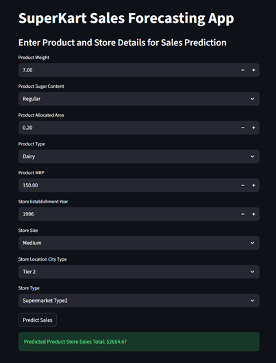

# **Actionable Insights and Business Recommendations**

## **Analyzing Feature Importances**

[figure not shown]

```python
import matplotlib.pyplot as plt
import seaborn as sns
import pandas as pd

# 1. Access the best Random Forest model from grid_search_rf
best_rf_model_pipeline = grid_search_rf.best_estimator_

# 2. Extract feature importances from the 'regressor' step
feature_importances = best_rf_model_pipeline.named_steps['regressor'].feature_importances_

# 3. Obtain the names of the features generated by the preprocessor step
# Access the preprocessor step from the best pipeline
preprocessor = best_rf_model_pipeline.named_steps['preprocessor']

# Get feature names after preprocessing (including one-hot encoded categorical features)
# Ensure that the ColumnTransformer is fitted to X_train before calling get_feature_names_out
# This should already be handled by the grid_search_rf.fit(X_train, y_train) step
all_feature_names = preprocessor.get_feature_names_out()

# 4. Create a Pandas DataFrame with Feature and Importance
feature_importance_df = pd.DataFrame({
    'Feature': all_feature_names,
    'Importance': feature_importances
})

# 5. Sort the DataFrame in descending order
feature_importance_df = feature_importance_df.sort_values(by='Importance', ascending=False)

# 6. Select the top 20 most important features
top_features = feature_importance_df.head(20)

# 7. Create a horizontal bar plot
plt.figure(figsize=(12, 8))
sns.barplot(x='Importance', y='Feature', data=top_features, palette='viridis')
plt.title('Top 10 Most Important Features', fontsize=16)
plt.xlabel('Importance', fontsize=12)
plt.ylabel('Feature', fontsize=12)
plt.tight_layout()

# 8. Display the plot
plt.show()
```

After end-to-end analysis—from data exploration to training a Random Forest model with 93% accuracy ($R^2$)—we have identified the key drivers of sales revenue for SuperKart.

### **Key Drivers of Sales (Actionable Insights)**

Our model reveals that **Product Price/Weight** and **Store Type/Location** are the some of the strongest predictors of revenue, outweighing *product type*.

- The single most important predictor of sales is the product's price (`Product_MRP` or **Maximum Retail Price**). Higher-priced items drive higher total revenue than low-cost volume items.
- Surprisingly, `Product_Weight` is the second most important feature. This suggests that bulkier/heavier items are significant revenue contributors. (These could be bulk packs)
- Store type and city tier seems to be a strong factor as well. It might be worth it to explore store type and city/location relations with the data to understand what is actionable there.

### **Business Recommendations**

Based on these findings, we propose the following strategies for SuperKart:

#### **Initiate Inventory Optimizations**

- Utilize this UI to orient stocking with which stores are the most effective at selling them. This information can be learned from the model.

#### **Monitor the Model's Accuracy**

- Add reliable model monitoring to ensure the accuracy of the model so you can build business functions based on the model results.

#### **Increase Revenue: Pricing & Bundling**

- Since higher MRP correlates with higher revenue, customers are willing to pay for value.
- Introduce **Product Bundling**. For example, instead of selling single units of "Soft Drinks" promote "Family Packs" or bulk bundles. This leverages the two top features to drive up the transaction value.

```python
import nbformat
from nbconvert import HTMLExporter
import io

# --- CONFIGURATION ---
notebook_path = "/content/drive/My Drive/Colab/MD Proj/Full_Code_SuperKart.ipynb"
output_html_path = "/content/drive/My Drive/Colab/MD Proj/Full_Code_SuperKart.html"
# ---------------------

print(f"Reading notebook from: {notebook_path}")

with io.open(notebook_path, 'r', encoding='utf-8') as f:
    nb = nbformat.read(f, as_version=4)

# Manually remove the widget state metadata if it exists.
if 'widgets' in nb.metadata:
    print("Found and removing problematic widget state metadata...")
    del nb.metadata['widgets']

html_exporter = HTMLExporter()
html_exporter.exclude_input = False

(body, resources) = html_exporter.from_notebook_node(nb)

with io.open(output_html_path, 'w', encoding='utf-8') as f:
    f.write(body)

print(f"✅ Successfully converted and saved HTML to: {output_html_path}")
```

```
Reading notebook from: /content/drive/My Drive/Colab/MD Proj/Full_Code_SuperKart.ipynb
Found and removing problematic widget state metadata...
✅ Successfully converted and saved HTML to: /content/drive/My Drive/Colab/MD Proj/Full_Code_SuperKart.html
```